# neuralnet_rmd

Ashirali Alibek

### Искуственные Нейронные сети на R

Искусственная нейронная сеть (ANN) представляет собой вычислительную нелинейную модель, основанную на нейронной структуре мозга, которая может научиться выполнять такие задачи, как классификация, прогнозирование, принятие решений, визуализация и другие, просто рассматривая примеры.

Искусственная нейронная сеть состоит из искусственных нейронов или элементов обработки и организована в три взаимосвязанных слоя: вход, скрытый, который может содержать более одного уровня, и выход.

Искусственная нейронная сеть (Artificial neural network) делится на четыре вида:

- Пиковая нейронная сеть (SNN) или другому Импульсная нейронная сеть (PNN)
- Свёрточная нейронная сеть (CNN)
- Рекуррентная нейронная сеть (RNN)
- Гибридная нейронная сетевая архитектура (HNNA)

Введение в искуственные нейронные сети

Нейронные сети ANN Широкий класс моделей, изначально создавались для моделирования работы мозга Существует много видов нейронных сетей. Они различаются в зависимости от  
- Решаемой задачи регрессия/прогнозирование, классификация, кластеризация  
- архитектуры модели  
- алгоритма обучения сети

Немного биологий • Дендриты – получают информацию  
• Тело клетки – обрабатывает информацию  
• Аксон – передает обработанную информацию другим нейронам  
• Синапсы – соединяют аксон и дендриты других нейронов

• X1 X2 … Xp от других нейронов или от рецепторов  
• Входы усиливаются или ослабляются умножением на веса w  
• I = линейная комбинация всех входов  
• Активационная функция f преобразует сумму в выходной сигнал  
• Выходной сигнал поступает к другим нейронам или является выходом нейронной сети

Некоторые активационные функций:

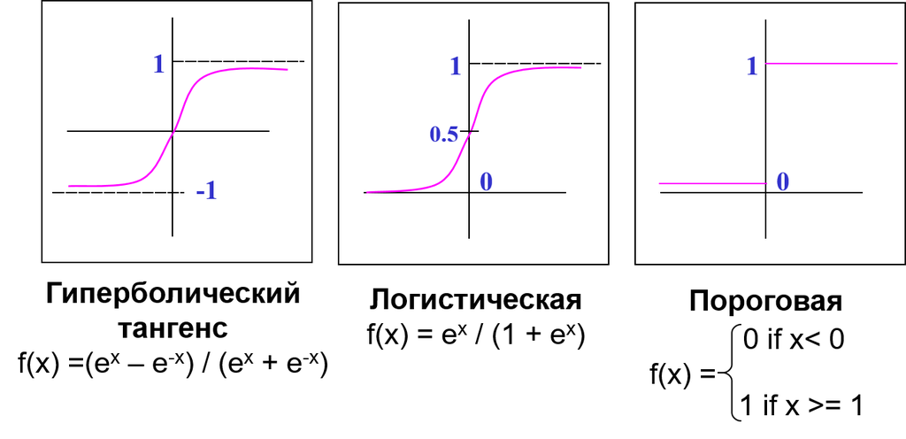

Нейронные сети имеют различные слой, так как работа нейронов организована послойно * Входной слой - каждый нейрон имеет ровно один вход от внешней среды * Скрытый слой - входы — от каждого нейрона предыдущего слоя * Выходной слой - Выход каждого нейрона является реакцией сети

Входной слой и выходной слой обычно не считают так они являются передатчиками переменных, а где происходит вся магия так это в скрытом слое. Слоёв может быть 0, 1 ну или больше. *Важно запомнить нейроны передают информацию только следующим слоям*

Выбор модели ANN зависит от задачи ну и от аналитика, вот что стоит учитывать при выборе • входные нейроны • скрытые слоя • нейроны в каждом скрытом слое • выходные нейроны • активационная функция каждого нейрона • ВЕСА каждого соединения Обучение нейронной сети = определение значений весов. Остальные параметры задаются аналитиком заранее.

Давайте расмотрим как работают нейронные сети внутри “чёрного ящика”"

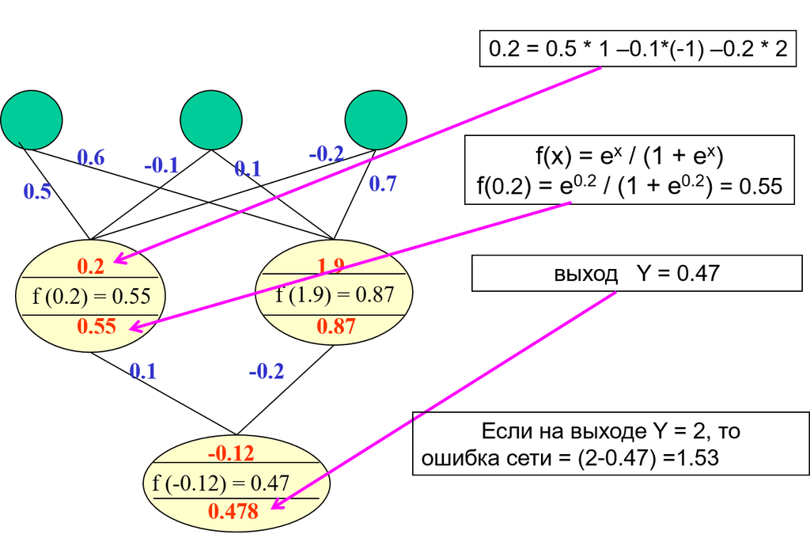